# Team DAY Project

Dustin Bracy, Adam Ruthford, Yang Zhang

1/23/2020

```r
library(tidyverse)
library(data.table) #for %like% function
library(xml2)
library(purrr)
library(lubridate)
library(tictoc)
library(kableExtra)
library(car)
tic('total runtime')
load("./data/reports.RData")
load("./data/customGroups.RData")
load("./data/currencyCode.RData")
```

### Notes on Binning HourOfDay and Filtering by server

The HourOfDay variable is going to be binned so that we can examine the time of day as a categorical variable. This is in an effort to determine the best time of the day to run one of or schedule new reports. Servers 1 and 5 are test and development servers. Thus they do not impact the run times for production data.

```r
reports$HourBinned <- case_when(reports$HourOfDay %in% c("06","07") ~ "0607",
                                    reports$HourOfDay %in% c("08","09") ~ "0809",
                                    reports$HourOfDay %in% c("10","11")~ "1011",
                                    reports$HourOfDay %in% c("12","13")~ "1213",
                                    reports$HourOfDay %in% c("14","15")~ "1415",
                                    reports$HourOfDay %in% c("16","17")~ "1617",
                                    reports$HourOfDay %in% c("18","19","20","21","22","23")~ "1823",
                                    reports$HourOfDay %in% c("00","01","02","03","04","05")~ "0005",
                                    TRUE~"OTHER")

reportsfilter <- reports %>% filter(!Server == "SQLODR1" & !Server == "SQLODR5")
```

## Two way Anova

### Unlogged response variable Summary Stats and ANOVA table

```r
model.fit.HrBnSrv <- aov(ReportDeliveryTime~Server+HourBinned+RptFrmt:Server, data = reportsfilter)
Anova(model.fit.HrBnSrv,type=3,singular.ok=TRUE)
```

```
## Note: model has aliased coefficients
##       sums of squares computed by model comparison
```

```
## Anova Table (Type III tests)
##
## Response: ReportDeliveryTime
##                    Sum Sq     Df  F values    Pr(>F)
## Server         4.7287e+08      2    5.5683  0.003818 **
## HourBinned     1.7186e+12      7 5782.2857 < 2.2e-16 ***
## Server:RptFrmt 1.9470e+11     14  327.5263 < 2.2e-16 ***
## Residuals      1.1215e+13 264122
## ---
## Signif. codes:  0 '***' 0.001 '**' 0.01 '*' 0.05 '.' 0.1 ' ' 1
```

```r
mysummary<-function(x){
  result<-c(length(x),mean(x),sd(x),sd(x)/length(x))
  names(result)<-c("N","Mean","SD","SE")
  return(result)
}
sumstats<-aggregate(ReportDeliveryTime~HourBinned:Server,data=reportsfilter,mysummary)
sumstats<-cbind(sumstats[,1:2],sumstats[,-(1:2)])
sumstats
```

```
##    HourBinned  Server     N      Mean        SD          SE
## 1        0005 SQLODR2   146 70710.585 13447.407  92.1055308
## 2        0607 SQLODR2 38992  2069.500  5650.167   0.1449058
## 3        0809 SQLODR2 18181  1701.311  5535.465   0.3044643
## 4        1011 SQLODR2  7507  3014.323  5977.497   0.7962565
## 5        1213 SQLODR2  5663  2887.073 12045.504   2.1270536
## 6        1415 SQLODR2  6182  1350.456  5632.289   0.9110788
## 7        1617 SQLODR2  3594  3680.704  9329.157   2.5957589
## 8        1823 SQLODR2 12123  2241.170  8225.645   0.6785156
## 9        0005 SQLODR3    90 70605.728 13653.813 151.7090337
## 10       0607 SQLODR3 29696  1897.358  4254.414   0.1432656
## 11       0809 SQLODR3 16106  1406.260  5930.755   0.3682326
## 12       1011 SQLODR3  6117  2597.394  6872.978   1.1235864
## 13       1213 SQLODR3  5013  2610.538 10537.907   2.1021160
## 14       1415 SQLODR3  5390  1607.644  6097.106   1.1311886
## 15       1617 SQLODR3  3189  3018.047  8024.030   2.5161588
## 16       1823 SQLODR3 10753  1705.270  6666.209   0.6199395
## 17       0005 SQLODR6   148 67076.759 13543.479  91.5099905
## 18       0607 SQLODR6 40038  2066.295  4674.071   0.1167409
## 19       0809 SQLODR6 18544  1738.431  5776.866   0.3115221
## 20       1011 SQLODR6  7821  3425.258  9215.824   1.1783434
## 21       1213 SQLODR6  5761  2313.618 13048.505   2.2649723
## 22       1415 SQLODR6  6451  1505.762  5941.445   0.9210114
## 23       1617 SQLODR6  3501  2783.186  8544.389   2.4405568
## 24       1823 SQLODR6 13140  1751.217  7074.765   0.5384144
```

### Discussion

ANOVA table does show that interaction as well as explanatory variables are significant. The summary statistics include big differences in standard deviation.

### Unlogged response variable Residual plots

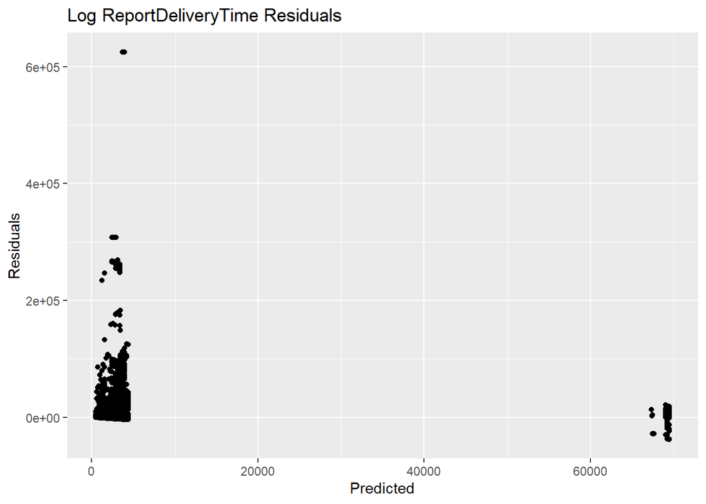

```r
myfits<-data.frame(fitted.values=model.fit.HrBnSrv$fitted.values,residuals=model.fit.HrBnSrv$residuals)

#Residual vs Fitted

plot1<-ggplot(myfits,aes(x=fitted.values,y=residuals))+ylab("Residuals")+
  xlab("Predicted")+geom_point()+ggtitle("Log ReportDeliveryTime Residuals")

#QQ plot of residuals  #Note the diagonal abline is only good for qqplots of normal data.
plot2<-ggplot(myfits,aes(sample=residuals))+
  stat_qq()+geom_abline(intercept=mean(myfits$residuals), slope = sd(myfits$residuals))+
  ggtitle("Log ReportDeliveryTime Q-Q plot")

#Histogram of residuals
plot3<-ggplot(myfits, aes(x=residuals)) +
  geom_histogram(aes(y=..density..),binwidth=1,color="black", fill="gray")+
  geom_density(alpha=.1, fill="red")+
  ggtitle("Log ReportDeliveryTime Histogram")

plot1
```

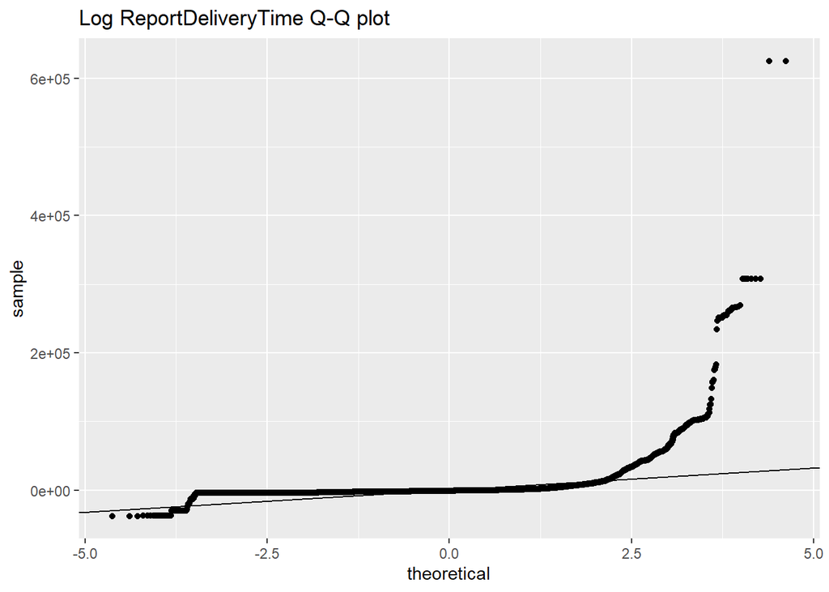

```r
plot2
```

```r
# plot3 Don't run this one takes too long and we are not going to use it anyway
```

### Discussion

The residual plots is unacceptable. The Q-Q plot demonstrates significant issues as well. A log transformation will be used to correct these problems

## Two way Anova

### Logged response variable Summary Stats and ANOVA table

```r
reportsfilter$ReportDeliveryTimeLog <- log(reportsfilter$ReportDeliveryTime)
model.fit.HrBnSrvlg <- aov(ReportDeliveryTimeLog~Server+HourBinned+RptFrmt:Server, data = reportsfilter)
Anova(model.fit.HrBnSrvlg,type=3,singular.ok=TRUE)
```

```
## Note: model has aliased coefficients
##       sums of squares computed by model comparison
```

```
## Anova Table (Type III tests)
##
## Response: ReportDeliveryTimeLog
##                Sum Sq     Df  F values    Pr(>F)
## Server            191      2    27.074 1.751e-12 ***
## HourBinned     255759      7 10367.121 < 2.2e-16 ***
## Server:RptFrmt  17574     14   356.187 < 2.2e-16 ***
## Residuals      930844 264121
## ---
## Signif. codes:  0 '***' 0.001 '**' 0.01 '*' 0.05 '.' 0.1 ' ' 1
```

```r
mysummary<-function(x){
  result<-c(length(x),mean(x),sd(x),sd(x)/length(x))
  names(result)<-c("N","Mean","SD","SE")
  return(result)
}
sumstats<-aggregate(ReportDeliveryTimeLog~HourBinned:Server,data=reportsfilter,mysummary)
sumstats<-cbind(sumstats[,1:2],sumstats[,-(1:2)])
sumstats
```

```
##    HourBinned  Server     N      Mean        SD           SE
## 1        0005 SQLODR2   146 11.140575 0.2504483 1.715399e-03
## 2        0607 SQLODR2 38992  7.150956 1.2098662 3.102858e-05
## 3        0809 SQLODR2 18181  5.721522 2.0279140 1.115403e-04
## 4        1011 SQLODR2  7507  5.175466 2.8435655 3.787885e-04
## 5        1213 SQLODR2  5663  4.690601 2.6324906 4.648580e-04
## 6        1415 SQLODR2  6182  4.771784 2.3045847 3.727895e-04
## 7        1617 SQLODR2  3594  5.411735 2.7568997 7.670840e-04
## 8        1823 SQLODR2 12123  5.699633 1.8391889 1.517107e-04
## 9        0005 SQLODR3    90 11.140112 0.2407437 2.674930e-03
## 10       0607 SQLODR3 29696  7.089606 1.1753883 3.958070e-05
## 11       0809 SQLODR3 16106  5.544000 1.9477622 1.209339e-04
## 12       1011 SQLODR3  6117  4.905047 2.7517530 4.498534e-04
## 13       1213 SQLODR3  5013  4.531609 2.5394046 5.065638e-04
## 14       1415 SQLODR3  5390  4.790993 2.3825021 4.420226e-04
## 15       1617 SQLODR3  3189  5.139995 2.7571554 8.645831e-04
## 16       1823 SQLODR3 10753  5.588287 1.7965752 1.670766e-04
## 17       0005 SQLODR6   148 11.087494 0.2451263 1.656259e-03
## 18       0607 SQLODR6 40038  7.152551 1.2098234 3.021688e-05
## 19       0809 SQLODR6 18544  5.658809 2.0811376 1.122270e-04
## 20       1011 SQLODR6  7821  5.071286 2.9027346 3.711462e-04
## 21       1213 SQLODR6  5761  4.297178 2.5217295 4.377243e-04
## 22       1415 SQLODR6  6450  4.768409 2.3634306 3.664233e-04
## 23       1617 SQLODR6  3501  4.907275 2.6897266 7.682738e-04
## 24       1823 SQLODR6 13140  5.584074 1.7756054 1.351298e-04
```

### Discussion

ANOVA table does show that interaction as well as explanatory variables are significant, the p-value has decreased on the “server” variable. The summary statistics standard deviation is more consistent but has intersting patterns.

### Logged response variable Residual plots

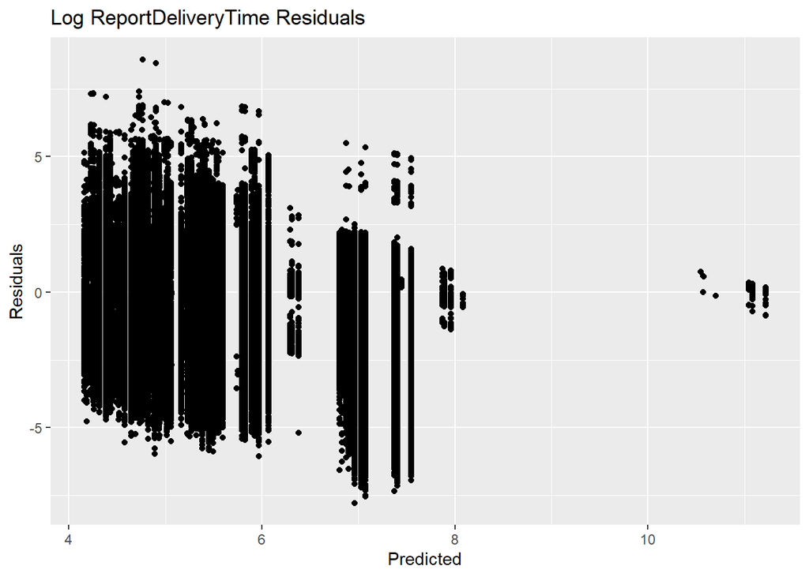

```r
myfits<-data.frame(fitted.values=model.fit.HrBnSrvlg$fitted.values,residuals=model.fit.HrBnSrvlg$residuals)

#Residual vs Fitted

plot1<-ggplot(myfits,aes(x=fitted.values,y=residuals))+ylab("Residuals")+
  xlab("Predicted")+geom_point()+ggtitle("Log ReportDeliveryTime Residuals")

#QQ plot of residuals  #Note the diagonal abline is only good for qqplots of normal data.
plot2<-ggplot(myfits,aes(sample=residuals))+
  stat_qq()+geom_abline(intercept=mean(myfits$residuals), slope = sd(myfits$residuals))+
  ggtitle("Log ReportDeliveryTime Q-Q plot")

#Histogram of residuals
plot3<-ggplot(myfits, aes(x=residuals)) +
  geom_histogram(aes(y=..density..),binwidth=1,color="black", fill="gray")+
  geom_density(alpha=.1, fill="red")+
  ggtitle("Log ReportDeliveryTime Histogram")

plot1
```

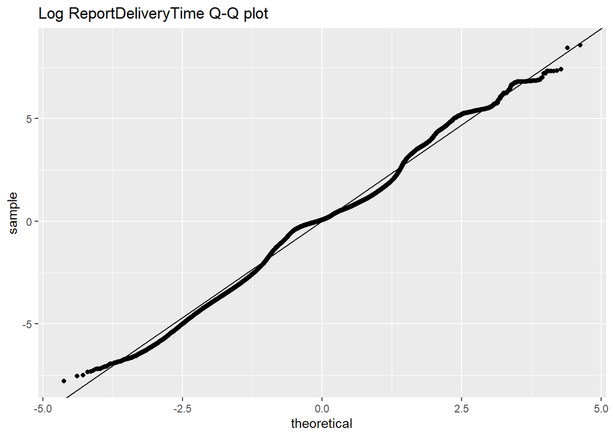

```r
plot2
```

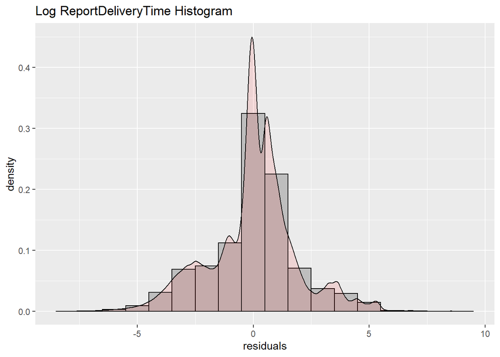

```r
plot3
```